# Final Project

Gurpreet Singh

December 9, 2017

### Prediction of House Sale Price

##### Installing required Libraries

```r
suppressWarnings(library(data.table))
suppressWarnings(library(corrplot))
suppressWarnings(library(ggplot2))
suppressWarnings(library(knitr))
suppressWarnings(library(Hmisc))
suppressWarnings(library(MASS))
suppressWarnings(library(forecast))
```

#### Data

```r
houses <- fread("C:/Users/Gurpreet/Documents/IS605/train.csv")

names(houses) <- tolower(gsub(" ", "_", names(houses)))

str(houses)
```

```
## Classes 'data.table' and 'data.frame':   1460 obs. of  81 variables:
##  $ id           : int  1 2 3 4 5 6 7 8 9 10 ...
##  $ mssubclass   : int  60 20 60 70 60 50 20 60 50 190 ...
##  $ mszoning     : chr  "RL" "RL" "RL" "RL" ...
##  $ lotfrontage  : int  65 80 68 60 84 85 75 NA 51 50 ...
##  $ lotarea      : int  8450 9600 11250 9550 14260 14115 10084 10382 6120 7420 ...
##  $ street       : chr  "Pave" "Pave" "Pave" "Pave" ...
##  $ alley        : chr  NA NA NA NA ...
##  $ lotshape     : chr  "Reg" "Reg" "IR1" "IR1" ...
##  $ landcontour  : chr  "Lvl" "Lvl" "Lvl" "Lvl" ...
##  $ utilities    : chr  "AllPub" "AllPub" "AllPub" "AllPub" ...
##  $ lotconfig    : chr  "Inside" "FR2" "Inside" "Corner" ...
##  $ landslope    : chr  "Gtl" "Gtl" "Gtl" "Gtl" ...
##  $ neighborhood : chr  "CollgCr" "Veenker" "CollgCr" "Crawfor" ...
##  $ condition1   : chr  "Norm" "Feedr" "Norm" "Norm" ...
```

[output cut: 68 more lines]

```r
dim(houses)
```

```
## [1] 1460   81
```

```r
kable(head(houses))
```

| id | mssubclass | mszoning | lotfrontage | lotarea | street | alley | lotshape | landcontour | utilities | lotconfig | landslope | neighborhood | condition1 | condition2 | bldgtype | housestyle | overallqual | overallcond | yearbuilt | yearremodadd | roofstyle | roofmatl | exterior1st | exterior2nd | masvnrtype | masvnrarea | exterqual | extercond | foundation | … |
| --- | --- | --- | --- | --- | --- | --- | --- | --- | --- | --- | --- | --- | --- | --- | --- | --- | --- | --- | --- | --- | --- | --- | --- | --- | --- | --- | --- | --- | --- | --- |
| 1 | 60 | RL | 65 | 8450 | Pave | NA | Reg | Lvl | AllPub | Inside | Gtl | CollgCr | Norm | Norm | 1Fam | 2Story | 7 | 5 | 2003 | 2003 | Gable | CompShg | VinylSd | VinylSd | BrkFace | 196 | Gd | TA | PConc | … |
| 2 | 20 | RL | 80 | 9600 | Pave | NA | Reg | Lvl | AllPub | FR2 | Gtl | Veenker | Feedr | Norm | 1Fam | 1Story | 6 | 8 | 1976 | 1976 | Gable | CompShg | MetalSd | MetalSd | None | 0 | TA | TA | CBlock | … |
| 3 | 60 | RL | 68 | 11250 | Pave | NA | IR1 | Lvl | AllPub | Inside | Gtl | CollgCr | Norm | Norm | 1Fam | 2Story | 7 | 5 | 2001 | 2002 | Gable | CompShg | VinylSd | VinylSd | BrkFace | 162 | Gd | TA | PConc | … |
| 4 | 70 | RL | 60 | 9550 | Pave | NA | IR1 | Lvl | AllPub | Corner | Gtl | Crawfor | Norm | Norm | 1Fam | 2Story | 7 | 5 | 1915 | 1970 | Gable | CompShg | Wd Sdng | Wd Shng | None | 0 | TA | TA | BrkTil | … |
| 5 | 60 | RL | 84 | 14260 | Pave | NA | IR1 | Lvl | AllPub | FR2 | Gtl | NoRidge | Norm | Norm | 1Fam | 2Story | 8 | 5 | 2000 | 2000 | Gable | CompShg | VinylSd | VinylSd | BrkFace | 350 | Gd | TA | PConc | … |
| 6 | 50 | RL | 85 | 14115 | Pave | NA | IR1 | Lvl | AllPub | Inside | Gtl | Mitchel | Norm | Norm | 1Fam | 1.5Fin | 5 | 5 | 1993 | 1995 | Gable | CompShg | VinylSd | VinylSd | None | 0 | TA | TA | Wood | … |

##### Missing Values and NA’s

Handling missing values in the berginning to perform analysis smoothly later on. Creating a dataframe for columns of the dataframe houses to remove NA’swith required values(variables). Table out the values connecting each other to analyze NA’s and remove or replace with required data. In our dataset garage condition, garage type, garage condition are interlinked, creating pairs to check this and handle the missing values.

```r
df_na<- data.frame(colSums(is.na(houses)))
names(df_na)<- c( "na")




kable(table(houses$poolqc,houses$poolarea, useNA = 'ifany'))
```

|  | 0 | 480 | 512 | 519 | 555 | 576 | 648 | 738 |
| --- | --- | --- | --- | --- | --- | --- | --- | --- |
| Ex | 0 | 0 | 1 | 0 | 1 | 0 | 0 | 0 |
| Fa | 0 | 0 | 0 | 1 | 0 | 0 | 1 | 0 |
| Gd | 0 | 1 | 0 | 0 | 0 | 1 | 0 | 1 |
| NA | 1453 | 0 | 0 | 0 | 0 | 0 | 0 | 0 |

```r
## 1,453 NA's with poolarea 0. assuming there is no pool, replace with "None"
houses$poolqc[is.na(houses$poolqc)]<- "None"

## Using similar technique for fire places
table(houses$fireplacequ,houses$fireplaces,useNA = 'ifany')
```

```
##
##          0   1   2   3
##   Ex     0  19   4   1
##   Fa     0  28   4   1
##   Gd     0 324  54   2
##   Po     0  20   0   0
##   TA     0 259  53   1
##   <NA> 690   0   0   0
```

```r
houses$fireplacequ[is.na(houses$fireplacequ)] <- "None"




## missing values for allcolumns related to garage, assuming no garage at all
#table(houses$garagetype,houses$garageyrblt,useNA = 'ifany')


houses$garagetype[is.na(houses$garagetype)] <- "None"
houses$garageyrblt[is.na(houses$garageyrblt)] <- ""
houses$garagecond[is.na(houses$garagecond)] <- "None"
houses$garagefinish[is.na(houses$garagefinish)] <- "None"
houses$garagequal[is.na(houses$garagequal)] <- "None"



## another category
table(is.na(houses$masvnrarea),is.na(houses$masvnrtype))
```

```
##
##         FALSE TRUE
##   FALSE  1452    0
##   TRUE      0    8
```

```r
houses$masvnrtype[is.na(houses$masvnrtype)] <- "None"
houses$masvnrarea[is.na(houses$masvnrarea)] <- 0


##for basement

table(houses$bsmtfintype1,houses$bsmtfintype2, useNA = 'ifany')
```

```
##
##        ALQ BLQ GLQ LwQ Rec Unf <NA>
##   ALQ    0  15   2  15  22 166    0
##   BLQ    2   1   5  13  15 112    0
##   GLQ    4   2   0  10   9 392    1
##   LwQ    9   4   7   0   8  46    0
##   Rec    4  11   0   8   0 110    0
##   Unf    0   0   0   0   0 430    0
##   <NA>   0   0   0   0   0   0   37
```

```r
houses$bsmtfintype1[is.na(houses$bsmtfintype1)] <- "None"
houses$bsmtfintype2[is.na(houses$bsmtfintype2)] <- "None"

table(houses$bsmtqual,houses$bsmtcond, useNA = 'ifany')
```

```
##
##         Fa  Gd  Po  TA <NA>
##   Ex     0  11   0 110    0
##   Fa     8   0   2  25    0
##   Gd     2  36   0 580    0
##   TA    35  18   0 596    0
##   <NA>   0   0   0   0   37
```

```r
houses$bsmtqual[is.na(houses$bsmtqual)] <- "None"
houses$bsmtcond[is.na(houses$bsmtcond)] <- "None"
houses$bsmtexposure[is.na(houses$bsmtexposure)] <- "None"
## we can replace basement exposure  with "No" as it is included in the values, we assume it is different than ##having a basement with no exposure or no basement at all



### misc. columns
houses$miscfeature[is.na(houses$miscfeature)] <- "None"
houses$fence[is.na(houses$fence)] <- "None"
houses$alley[is.na(houses$alley)] <- "None"
houses$lotfrontage[is.na(houses$lotfrontage)] <- 0
houses$electrical[is.na(houses$electrical)] <- "None"




colSums(is.na(houses))
```

```
##            id    mssubclass      mszoning   lotfrontage       lotarea
##             0             0             0             0             0
##        street         alley      lotshape   landcontour     utilities
##             0             0             0             0             0
##     lotconfig     landslope  neighborhood    condition1    condition2
##             0             0             0             0             0
##      bldgtype    housestyle   overallqual   overallcond     yearbuilt
##             0             0             0             0             0
##  yearremodadd     roofstyle      roofmatl   exterior1st   exterior2nd
##             0             0             0             0             0
##    masvnrtype    masvnrarea     exterqual     extercond    foundation
##             0             0             0             0             0
##      bsmtqual      bsmtcond  bsmtexposure  bsmtfintype1    bsmtfinsf1
##             0             0             0             0             0
##  bsmtfintype2    bsmtfinsf2     bsmtunfsf   totalbsmtsf       heating
##             0             0             0             0             0
##     heatingqc    centralair    electrical      1stflrsf      2ndflrsf
##             0             0             0             0             0
##  lowqualfinsf     grlivarea  bsmtfullbath  bsmthalfbath      fullbath
##             0             0             0             0             0
##      halfbath  bedroomabvgr  kitchenabvgr   kitchenqual  totrmsabvgrd
##             0             0             0             0             0
##    functional    fireplaces   fireplacequ    garagetype   garageyrblt
##             0             0             0             0             0
##  garagefinish    garagecars    garagearea    garagequal    garagecond
##             0             0             0             0             0
##    paveddrive    wooddecksf   openporchsf enclosedporch     3ssnporch
##             0             0             0             0             0
##   screenporch      poolarea        poolqc         fence   miscfeature
##             0             0             0             0             0
##       miscval        mosold        yrsold      saletype salecondition
##             0             0             0             0             0
##     saleprice
##             0
```

```r
## no misiing values, we can move forward with the analysis.
```

Another required check is to find unique levels of categorical variables.Categories are incorrectly entered as lower case or first letter is capitalized. e.g. column misc feature has the categoies

“None” “Shed” “Gar2” “Othr” “TenC”. We can perform a check at the variables if the data is correct. “Othr” “othr” might corresponds to same category. Random check was performed on few categorical variables. Based on the variables required for analysis, this can be performed on them.

```r
## performing a random check at cat. variables.

unique(houses$extercond)
```

```
## [1] "TA" "Gd" "Fa" "Po" "Ex"
```

```r
unique(houses$extercond)
```

```
## [1] "TA" "Gd" "Fa" "Po" "Ex"
```

```r
unique(houses$miscval)
```

```
##  [1]     0   700   350   500   400   480   450 15500  1200   800  2000
## [12]   600  3500  1300    54   620   560  1400  8300  1150  2500
```

```r
unique(houses$street)
```

```
## [1] "Pave" "Grvl"
```

## Selecting Variables for Probability

Pick one of the quantitative independent variables from the training data set (train.csv) , and define that variable as X. Pick SalePrice as the dependent variable, and define it as Y for the next analysis.

The variable to be selected for the prediction is lot area.Variable X will be the lot area and vriable Y is described as the slae price.

```r
X<- houses$lotarea
Y<- houses$saleprice
```

Plotting the variables.

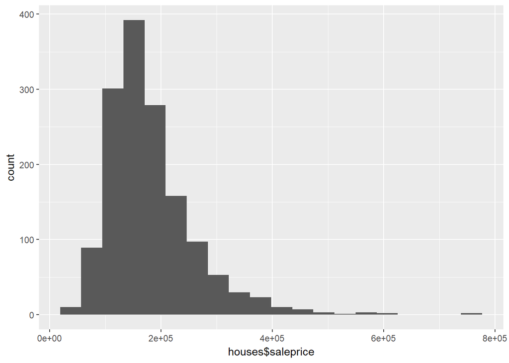

```r
ggplot(data=houses, aes(houses$saleprice)) + geom_histogram(bins=20)
```

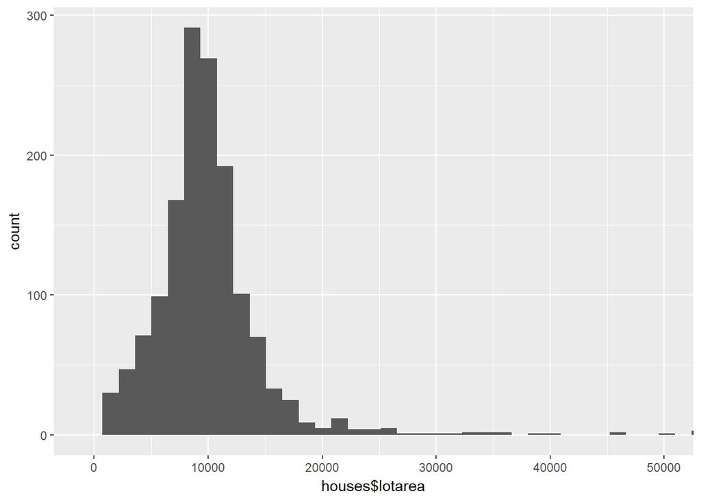

```r
ggplot(data=houses, aes(houses$lotarea)) + geom_histogram(bins=150) +coord_cartesian(xlim = c(-1000, 50000))
```

##### Probability :

Calculate as a minimum the below probabilities a through c. Assume the small letter “x” is estimated as the 1st quartile of the X variable, and the small letter “y” is estimated as the 2d quartile of the Y variable. Interpret the meaning of all probabilities

```r
## first quartile of X
x <- quantile(X, .25)

x
```

```
##    25%
## 7553.5
```

```r
## second quartile of Y
y<- quantile(Y,.50)
y
```

```
##    50%
## 163000
```

#### Probability

1. P(X>x|Y>y) Probability of X greater than first quartile of X (7553.5 ) given that Y is greater than 2nd quartile of Y (163,000).

```r
p_X <- nrow(houses[(houses$lotarea > x),])/nrow(houses)
p_X_and_Y <- nrow(houses[(houses$lotarea > x &houses$saleprice > y),])/nrow(houses)
p_Y <- nrow(houses[houses$saleprice> y,])/nrow(houses)

p_X_given_Y <- p_X_and_Y/p_Y

p_X_given_Y
```

```
## [1] 0.8653846
```

2. P(X>x & Y>y) Probability that X is greater than first qurtile of X (7553.5 ) and Y (sale price) is greater than second quartile of Y (163,000)

```r
p_X_and_Y
```

```
## [1] 0.4315068
```

```r
p_X_and_Y <- nrow(houses[(houses$lotarea < x &houses$saleprice > y),])/nrow(houses)
p_Y <- nrow(houses[houses$saleprice> y,])/nrow(houses)

p_X_given_Y <- p_X_and_Y/p_Y

p_X_given_Y
```

```
## [1] 0.1346154
```

Does splitting the training data in this fashion make them independent? In other words, does P(X|Y)=P(X)P(Y))? Check mathematically, and then evaluate by running a Chi Square test for association.

For independence :

P(XY)= P(X)P(Y) or

P(X|Y) = P(X)

```r
p_X_and_Y == p_X * p_Y
```

```
## [1] FALSE
```

##### Chi-Square Test

H<sub>0</sub> : Sale Price and Lot Area are independent

H<sub>a</sub> : Sale Price and Lot Area are not independent

```r
chisq.test(houses$saleprice,houses$lotarea)
```

```
##
##  Pearson's Chi-squared test
##
## data:  houses$saleprice and houses$lotarea
## X-squared = 735090, df = 709660, p-value < 2.2e-16
```

p-value is very small, we will reject null hypothesis. The variables are dependent. Lot area does effects the sale price of house.

##### Descriptive nd Inferential Statistics :

Provide univariate descriptive statistics and appropriate plots for both variables. Provide a scatterplot of X and Y. Transform both variables simultaneously using Box-Cox transformations. You might have to research this.

```r
describe(houses$saleprice)
```

```
## houses$saleprice
##        n  missing distinct     Info     Mean      Gmd      .05      .10
##     1460        0      663        1   180921    81086    88000   106475
##      .25      .50      .75      .90      .95
##   129975   163000   214000   278000   326100
##
## lowest :  34900  35311  37900  39300  40000, highest: 582933 611657 625000 745000 755000
```

```r
describe(houses$overallqual)
```

```
## houses$overallqual
##        n  missing distinct     Info     Mean      Gmd      .05      .10
##     1460        0       10    0.951    6.099    1.522        4        5
##      .25      .50      .75      .90      .95
##        5        6        7        8        8
##
## Value          1     2     3     4     5     6     7     8     9    10
## Frequency      2     3    20   116   397   374   319   168    43    18
## Proportion 0.001 0.002 0.014 0.079 0.272 0.256 0.218 0.115 0.029 0.012
```

```r
summary(houses$saleprice)
```

```
##    Min. 1st Qu.  Median    Mean 3rd Qu.    Max.
##   34900  129975  163000  180921  214000  755000
```

```r
summary(houses$lotarea)
```

```
##    Min. 1st Qu.  Median    Mean 3rd Qu.    Max.
##    1300    7554    9478   10517   11602  215245
```

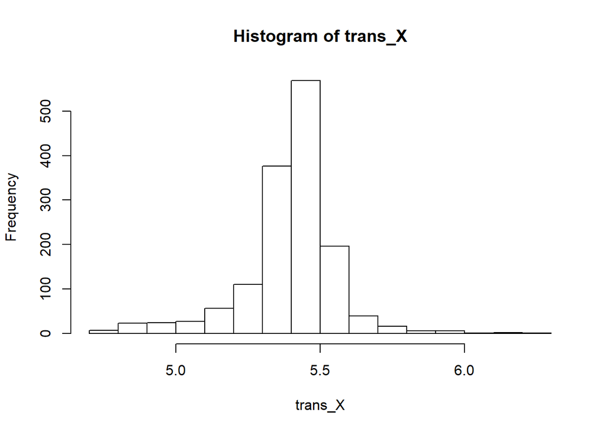

```r
## transform using boxcox transformation for normality

lambda_X = BoxCox.lambda(X)
trans_X<-  BoxCox(X,lambda_X)




lambda_Y<- BoxCox.lambda(Y)
trans_Y <- BoxCox(Y,lambda_Y)
trans_df <- data.frame(trans_X, trans_Y)

hist(trans_X)
```

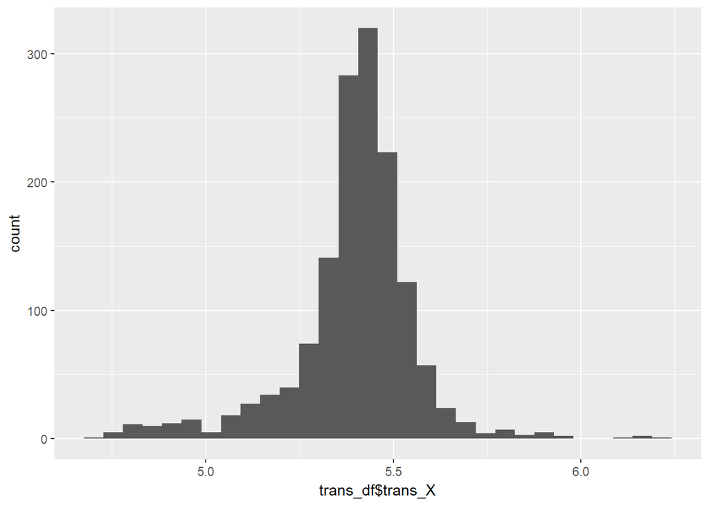

```r
ggplot(data=trans_df, aes(trans_df$trans_X)) + geom_histogram(bins=30)
```

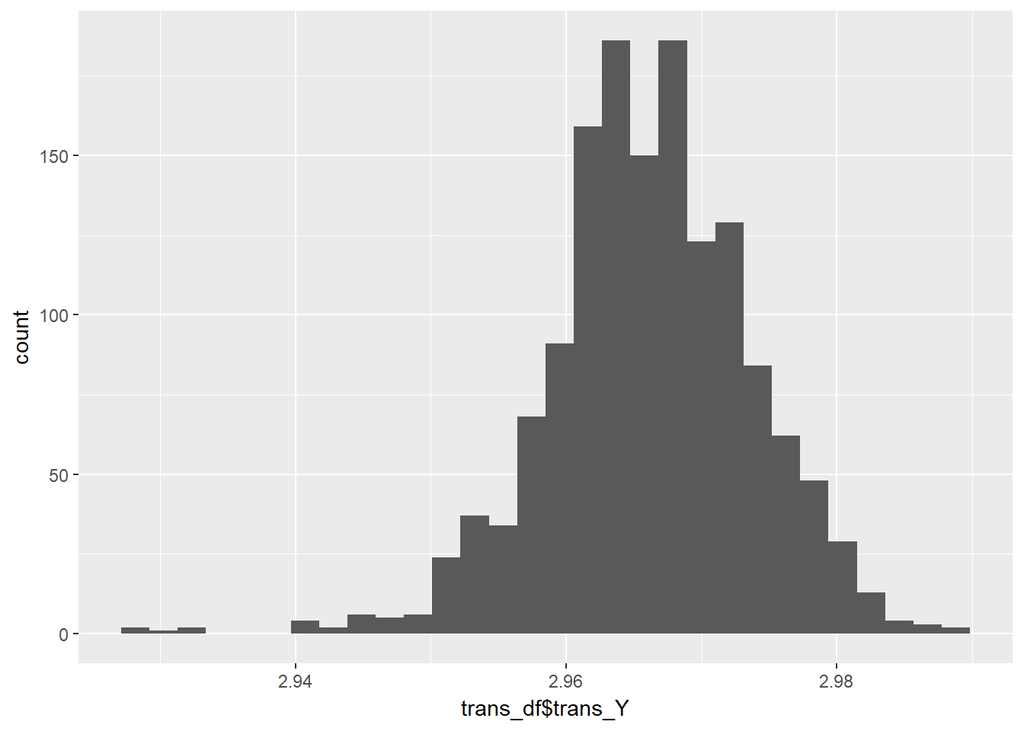

```r
ggplot(data=trans_df, aes(trans_df$trans_Y)) + geom_histogram(bins=30)
```

```r
##
```

Link: [boxcox](https://stackoverflow.com/questions/26617587/finding-optimal-lambda-for-box-cox-transform-in-r)

##### Linear Algebra and Correlation :

Using at least three untransformed variables, build a correlation matrix. Invert your correlation matrix. (This is known as the precision matrix and contains variance inflation factors on the diagonal.) Multiply the correlation matrix by the precision matrix, and then multiply the precision matrix by the correlation matrix

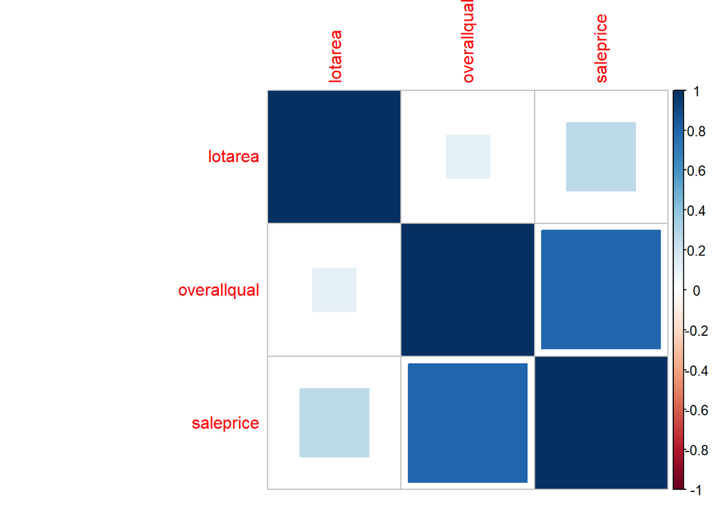

```r
houses1 <- houses[,c("lotarea", "overallqual", "saleprice")]
cor_matrix<-cor(houses1)
corrplot(cor_matrix, method = "square")
```

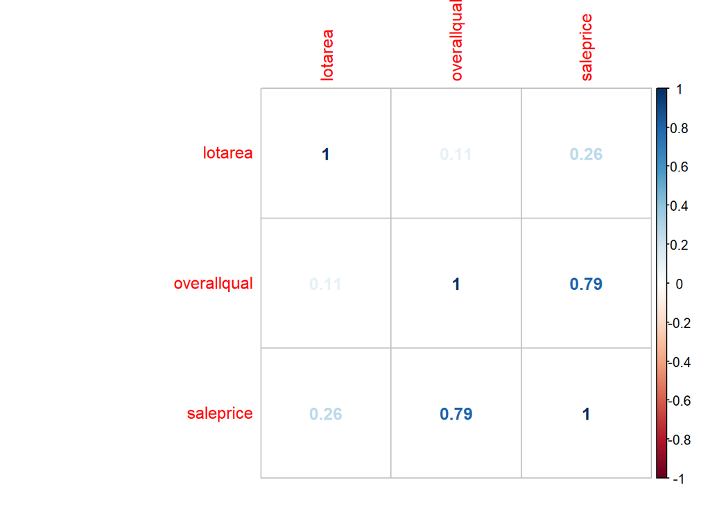

```r
corrplot(cor_matrix, method = "number")
```

```r
prec_matrix <- round(solve(cor_matrix),1)
prec_matrix
```

```
##             lotarea overallqual saleprice
## lotarea         1.1         0.3      -0.5
## overallqual     0.3         2.8      -2.3
## saleprice      -0.5        -2.3       2.9
```

```r
prec_cor<- round(cor_matrix%*%prec_matrix,1)
prec_cor
```

```
##             lotarea overallqual saleprice
## lotarea           1           0       0.0
## overallqual       0           1      -0.1
## saleprice         0           0       0.9
```

##### Calculus-Based Probability & Statistics.

Many times, it makes sense to fit a closed form distribution to data. For your non-transformed independent variable, location shift (if necessary) it so that the minimum value is above zero. Then load the MASS package and run fitdistr to fit a density function of your choice. (See https://stat.ethz.ch/R-manual/R-devel/library/MASS/html/fitdistr.html ). Find the optimal value of the parameters for this distribution, and then take 1000 samples from this distribution (e.g., rexp(1000, ???) for an exponential). Plot a histogram and compare it with a histogram of your non-transformed original variable

```r
min(houses$lotarea)
```

```
## [1] 1300
```

```r
## minimum value above zero, no location shift required


houses_fit <- fitdistr(houses$lotarea, 'normal')
mean_fit <- houses_fit$estimate[1]
sd_fit <- houses_fit$estimate[2]
mean_fit
```

```
##     mean
## 10516.83
```

```r
sd_fit
```

```
##       sd
## 9977.846
```

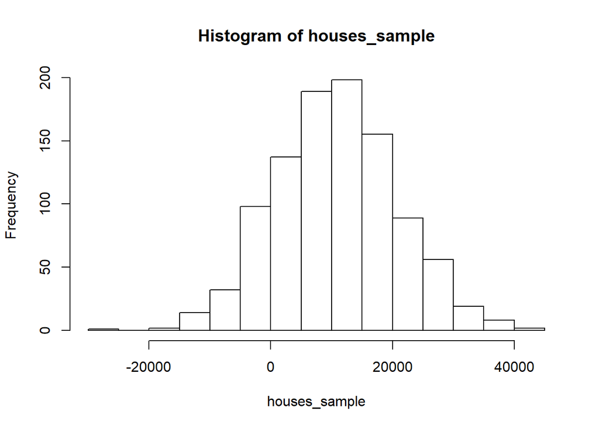

```r
houses_sample <-rnorm(1000,mean_fit, sd_fit)


hist(houses_sample)
```

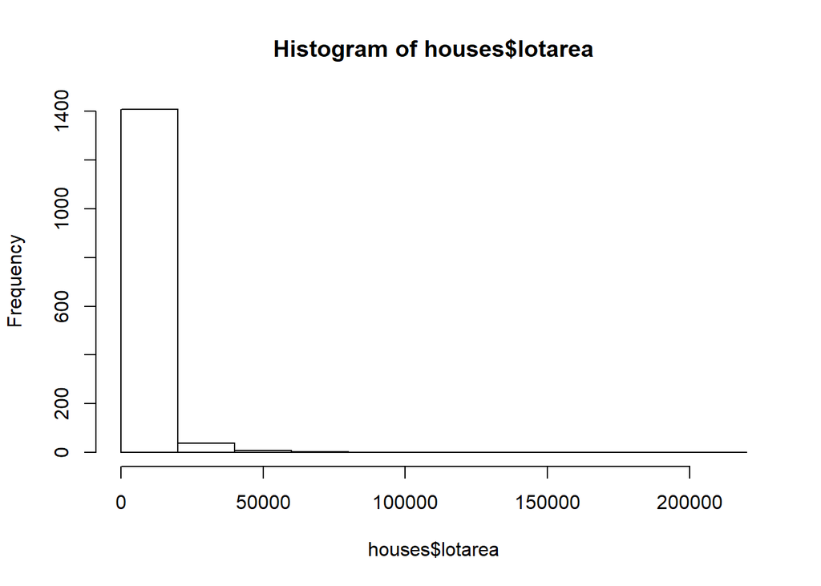

```r
hist(houses$lotarea)
```

```r
##nearly normal compared to original
```

##### Modeling:

Build some type of regression model and submit your model to the competition board. Provide your complete model summary and results with analysis. Report your Kaggle.com user name and score.

Multiple Regression model for prediction: 14 variabless were selected from the dataset for model. In order to avoid noise, the variable influencing ( in general) the saleprice of houses were selected.

```r
houses_cols <- houses[,c("saleprice", "mssubclass", "lotarea", "lotfrontage", "overallcond",                                       "overallqual", "grlivarea", "mosold", "yearbuilt", "yearremodadd",
                         "bedroomabvgr", "fullbath", "garagearea", "garagecars", "poolarea")]
```

```r
model <- lm(saleprice ~ .,data=houses_cols)

summary(model)
```

```
##
## Call:
## lm(formula = saleprice ~ ., data = houses_cols)
##
## Residuals:
##     Min      1Q  Median      3Q     Max
## -443561  -18954   -2210   15141  277561
##
## Coefficients:
##                Estimate Std. Error t value Pr(>|t|)
## (Intercept)  -1.182e+06  1.261e+05  -9.376  < 2e-16 ***
## mssubclass   -2.120e+02  2.445e+01  -8.671  < 2e-16 ***
## lotarea       6.576e-01  1.024e-01   6.421 1.83e-10 ***
## lotfrontage   1.537e+01  2.982e+01   0.515  0.60646
## overallcond   5.087e+03  1.047e+03   4.859 1.31e-06 ***
## overallqual   1.997e+04  1.159e+03  17.235  < 2e-16 ***
## grlivarea     6.986e+01  3.331e+00  20.975  < 2e-16 ***
## mosold       -1.368e+02  3.586e+02  -0.381  0.70291
## yearbuilt     4.720e+02  5.453e+01   8.656  < 2e-16 ***
## yearremodadd  9.751e+01  6.776e+01   1.439  0.15038
## bedroomabvgr -1.097e+04  1.525e+03  -7.194 1.00e-12 ***
## fullbath     -1.999e+03  2.643e+03  -0.756  0.44966
## garagearea    1.229e+01  9.985e+00   1.231  0.21863
## garagecars    9.646e+03  2.947e+03   3.273  0.00109 **
## poolarea     -2.268e+01  2.465e+01  -0.920  0.35774
## ---
## Signif. codes:  0 '***' 0.001 '**' 0.01 '*' 0.05 '.' 0.1 ' ' 1
##
## Residual standard error: 36840 on 1445 degrees of freedom
## Multiple R-squared:  0.787,  Adjusted R-squared:  0.785
## F-statistic: 381.5 on 14 and 1445 DF,  p-value: < 2.2e-16
```

R-squared value is 0.78. We will remove the variables with high p-value and update the model using backward elimination.

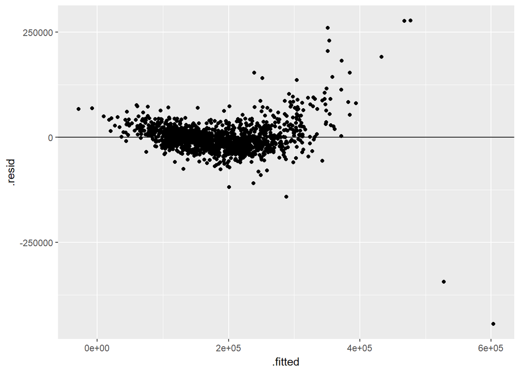

```r
ggplot(model, aes(x = .fitted, y = .resid)) + geom_point() +geom_hline(yintercept=0)+
  expand_limits(y = c(0, -800))
```

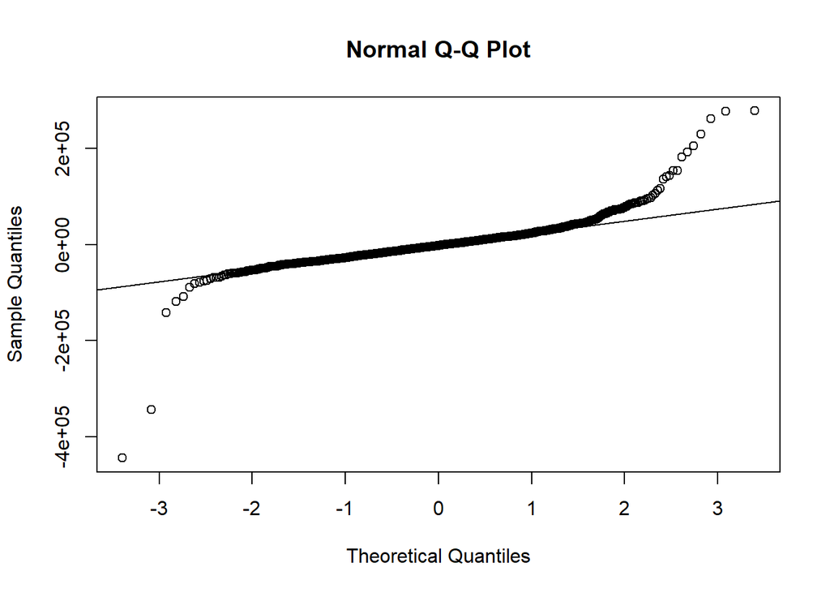

```r
qqnorm(model$residuals)
qqline(model$residuals)
```

```r
model <-update(model, .~. -mosold-lotfrontage-fullbath-poolarea-yearremodadd-garagearea, data = houses_cols)

summary(model)
```

```
##
## Call:
## lm(formula = saleprice ~ mssubclass + lotarea + overallcond +
##     overallqual + grlivarea + yearbuilt + bedroomabvgr + garagecars,
##     data = houses_cols)
##
## Residuals:
##     Min      1Q  Median      3Q     Max
## -438879  -19210   -2140   15409  276785
##
## Coefficients:
##                Estimate Std. Error t value Pr(>|t|)
## (Intercept)  -1.045e+06  8.999e+04 -11.615  < 2e-16 ***
## mssubclass   -2.206e+02  2.342e+01  -9.418  < 2e-16 ***
## lotarea       6.536e-01  1.021e-01   6.400 2.10e-10 ***
## overallcond   5.686e+03  9.574e+02   5.940 3.57e-09 ***
## overallqual   2.018e+04  1.140e+03  17.713  < 2e-16 ***
## grlivarea     6.994e+01  3.029e+00  23.087  < 2e-16 ***
## yearbuilt     4.981e+02  4.604e+01  10.819  < 2e-16 ***
## bedroomabvgr -1.160e+04  1.466e+03  -7.912 4.99e-15 ***
## garagecars    1.264e+04  1.765e+03   7.164 1.24e-12 ***
## ---
## Signif. codes:  0 '***' 0.001 '**' 0.01 '*' 0.05 '.' 0.1 ' ' 1
##
## Residual standard error: 36830 on 1451 degrees of freedom
## Multiple R-squared:  0.7863, Adjusted R-squared:  0.7851
## F-statistic: 667.3 on 8 and 1451 DF,  p-value: < 2.2e-16
```

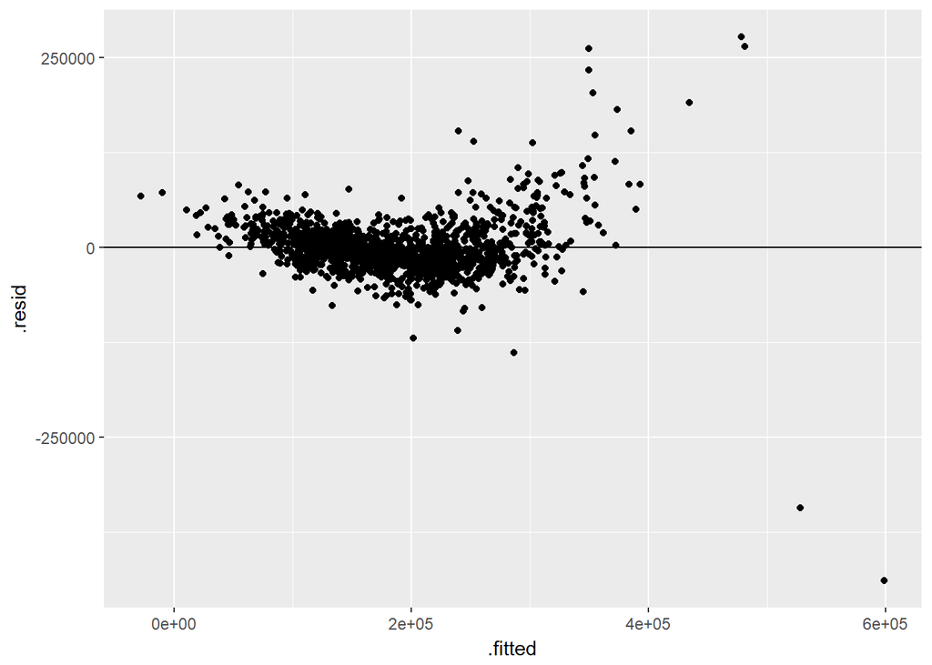

```r
ggplot(model, aes(x = .fitted, y = .resid)) + geom_point() +geom_hline(yintercept=0)+
  expand_limits(y = c(0, -800))
```

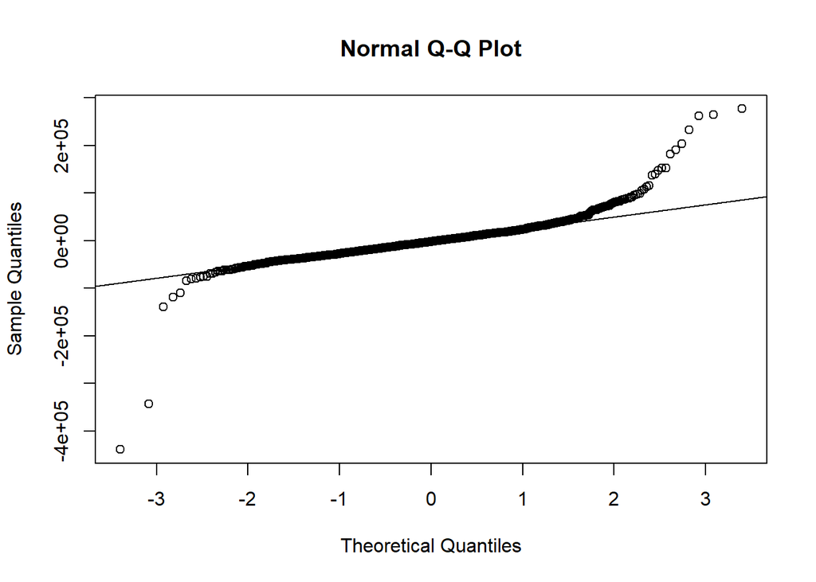

```r
qqnorm(model$residuals)
qqline(model$residuals)
```

###### Refrences :

https://cran.r-project.org/web/packages/corrplot/vignettes/corrplot-intro.html

https://stackoverflow.com/questions/26617587/finding-optimal-lambda-for-box-cox-transform-in-r

http://docs.statwing.com/interpreting-residual-plots-to-improve-your-regression/